# Práctica_final_M1-EDA_LLAP

**1-Une todos los dataframe desde Enero a Diciembre en un único dataframe. Muestra el shape total del dataframe resultante.**

```python
import pandas as pd
```

```python
#Ejemplo de leer un csv (después de varios errores se ve que hay un error de encoding utf-8, por lo que la cambié a 'latin1'
#y que tenga en cuenta el separador ';')

df = pd.read_csv("CSVs/202201_detalle.csv", sep = ";", encoding = "latin1")
df
```

|  | CALIFICACION | LUGAR | MES | ANIO | HORA | IMP_BOL | DESCUENTO | PUNTOS | DENUNCIANTE | HECHO-BOL | VEL_LIMITE | VEL_CIRCULA | COORDENADA-X | COORDENADA-Y |
| --- | --- | --- | --- | --- | --- | --- | --- | --- | --- | --- | --- | --- | --- | --- |
| 0 | LEVE | CL ALONSO CANO 95 | 1 | 2022 | 17.51 | 90.0 | SI | 0 | SER | ESTACIONAR, SIN LA CORRESPONDIENTE AUTORIZACIÓ... |  |  |  |  |
| 1 | LEVE | CL CRISTOBAL BORDIU 10 | 1 | 2022 | 18.00 | 90.0 | SI | 0 | SER | ESTACIONAR EN LUGAR PROHIBIDO. ... |  |  |  |  |
| 2 | GRAVE | CL ALENZA 28 | 1 | 2022 | 18.46 | 200.0 | SI | 0 | SER | ESTACIONAR OBSTACULIZANDO LA UTILIZACIÓN DE UN... |  |  |  |  |
| 3 | LEVE | CL ALONSO CANO 20 | 1 | 2022 | 19.59 | 90.0 | SI | 0 | SER | ESTACIONAR, SIN LA CORRESPONDIENTE AUTORIZACIÓ... |  |  |  |  |
| 4 | LEVE | CL ALONSO CANO 84 | 1 | 2022 | 20.04 | 60.0 | SI | 0 | SER | ESTACIONAR CON AUTORIZACIÓN NO VÁLIDA. ... |  |  |  |  |
| ... | ... | ... | ... | ... | ... | ... | ... | ... | ... | ... | ... | ... | ... | ... |
| 197800 | LEVE | GRAN VIA 6 | 1 | 2022 | 12.24 | 60.0 | SI | 0 | POLICIA MUNICIPAL | PARAR EN ZONA RESERVADAPARA USO EXCLUSIVO DEL ... |  |  |  |  |
| 197801 | LEVE | GRAN VIA 71 | 1 | 2022 | 11.06 | 60.0 | SI | 0 | POLICIA MUNICIPAL | PARAR EN ZONA RESERVADAPARA USO EXCLUSIVO DEL ... |  |  |  |  |
| 197802 | LEVE | GRAN VIA 6 | 1 | 2022 | 12.24 | 60.0 | SI | 0 | POLICIA MUNICIPAL | PARAR EN ZONA RESERVADAPARA USO EXCLUSIVO DEL ... |  |  |  |  |
| 197803 | LEVE | PRINCIPE DE VERGARA 54 | 1 | 2022 | 9.19 | 60.0 | SI | 0 | POLICIA MUNICIPAL | PARAR EN ZONA RESERVADAPARA USO EXCLUSIVO DEL ... |  |  |  |  |
| 197804 | LEVE | PRINCIPE DE VERGARA 75 | 1 | 2022 | 18.35 | 60.0 | SI | 0 | POLICIA MUNICIPAL | PARAR EN ZONA RESERVADAPARA USO EXCLUSIVO DEL ... |  |  |  |  |

197805 rows × 14 columns

```python
#Preparamos una lista vacía
dataframes = []

#Iterar sobre archivos CSV y cargar cada uno en un DataFrame separado utilizando la función read_csv
#de Pandas. Se puede utilizar la función glob de la biblioteca glob para obtener una lista de los
#archivos CSV en un directorio determinado:

import glob

#Ruta a los archivos CSV
ruta = "CSVs/*.csv"

#Itera sobre los archivos CSV, a tener en cuenta el separador y la codificación de caracteres "latinos"
for archivo_csv in glob.glob(ruta):
    df = pd.read_csv(archivo_csv, sep= ";", encoding= "latin1")
    dataframes.append(df)
```

```python
#Cargados todos los archivos CSV en DataFrames individuales y almacenados en la
#lista dataframes, los combinamos en un solo DataFrame utilizando la función concat de Pandas:

#Combina los DataFrames en uno solo
#El parámetro ignore_index=True se utiliza para restablecer los índices de fila en el DataFrame combinado.
df_combinado = pd.concat(dataframes, ignore_index=True)
```

```python
#Mostramos el shape resultante
df_combinado.shape
```

```
(2702125, 14)
```

```python
df_combinado
```

|  | CALIFICACION | LUGAR | MES | ANIO | HORA | IMP_BOL | DESCUENTO | PUNTOS | DENUNCIANTE | HECHO-BOL | VEL_LIMITE | VEL_CIRCULA | COORDENADA-X | COORDENADA-Y |
| --- | --- | --- | --- | --- | --- | --- | --- | --- | --- | --- | --- | --- | --- | --- |
| 0 | LEVE | CL ALONSO CANO 95 | 1 | 2022 | 17.51 | 90.0 | SI | 0 | SER | ESTACIONAR, SIN LA CORRESPONDIENTE AUTORIZACIÓ... |  |  |  |  |
| 1 | LEVE | CL CRISTOBAL BORDIU 10 | 1 | 2022 | 18.00 | 90.0 | SI | 0 | SER | ESTACIONAR EN LUGAR PROHIBIDO. ... |  |  |  |  |
| 2 | GRAVE | CL ALENZA 28 | 1 | 2022 | 18.46 | 200.0 | SI | 0 | SER | ESTACIONAR OBSTACULIZANDO LA UTILIZACIÓN DE UN... |  |  |  |  |
| 3 | LEVE | CL ALONSO CANO 20 | 1 | 2022 | 19.59 | 90.0 | SI | 0 | SER | ESTACIONAR, SIN LA CORRESPONDIENTE AUTORIZACIÓ... |  |  |  |  |
| 4 | LEVE | CL ALONSO CANO 84 | 1 | 2022 | 20.04 | 60.0 | SI | 0 | SER | ESTACIONAR CON AUTORIZACIÓN NO VÁLIDA. ... |  |  |  |  |
| ... | ... | ... | ... | ... | ... | ... | ... | ... | ... | ... | ... | ... | ... | ... |
| 2702120 | GRAVE | PO DELICIAS 68 | 12 | 2022 | 15.50 | 200.0 | SI | 0 | POLICIA MUNICIPAL | PARAR EN CARRIL BICI. ... |  |  |  |  |
| 2702121 | GRAVE | CAMINO GANAPANES, 33 | 12 | 2022 | 12.40 | 200.0 | SI | 0 | POLICIA MUNICIPAL | PARAR EN ZONA SEÑALIZADA PARA USO EXCLUSIVO DE... |  |  |  |  |
| 2702122 | MUY GRAVE | AV ORCASUR CON CÑALBAICIN | 12 | 2022 | 13.10 | 1000.0 | SI | 6 | POLICIA MUNICIPAL | CONDUCIR CON PRESENCIA DE DROGAS EN EL ORGANIS... |  |  |  |  |
| 2702123 | GRAVE | SINESIO DELGADO SÑN | 12 | 2022 | 20.59 | 200.0 | SI | 0 | POLICIA MUNICIPAL | CONDUCCIÓN NEGLIGENTE: CIRCULAR CAMBIANDO DE C... |  |  |  |  |
| 2702124 | GRAVE | NARVAEZ 29 | 12 | 2022 | 14.44 | 200.0 | SI | 0 | POLICIA MUNICIPAL | PARAR EN CARRIL BUS, OBSTACULIZANDO GRAVEMENTE... |  |  |  |  |

2702125 rows × 14 columns

**2-Como tal, no vamos a trabajar con datos geográficos, borra las columnas COORDENADA_X y COORDENADA_Y.**

```python
#Después de probar varias veces me decía que COORDENADA-Y no existia, por lo que miré los indices de las columnas
#Y vi que pasaba algo raro con la comentada anteriormente
df_combinado.columns
```

```
Index(['CALIFICACION', 'LUGAR', 'MES', 'ANIO', 'HORA', 'IMP_BOL', 'DESCUENTO',
       ' PUNTOS', 'DENUNCIANTE', 'HECHO-BOL', 'VEL_LIMITE', 'VEL_CIRCULA ',
       'COORDENADA-X',
       'COORDENADA-Y                                                                                                                                '],
      dtype='object')
```

```python
len(df_combinado.columns[-1])
```

```
140
```

```python
#Viendo que COORDENADA-Y tiene un problema, pensé dos métodos para arreglaro antes de borrar

#Cambiando el nombre de la columna antes
# df_combinado2 = df_combinado.rename(columns={df_combinado.columns[-1] : 'COORDENADA-Y'})
# df_combinado2
```

```python
#df_combinado2.columns
```

```python
#df_combinado3 = df_combinado2.drop(['COORDENADA-X', 'COORDENADA-Y'], axis=1)
#df_combinado3
```

```python
#Borrando su posición directamente. Con esta no haría falta renombrar con anterioridad
df_combinado3 = df_combinado.drop([df_combinado.columns[12], df_combinado.columns[13]], axis=1)
df_combinado3
```

|  | CALIFICACION | LUGAR | MES | ANIO | HORA | IMP_BOL | DESCUENTO | PUNTOS | DENUNCIANTE | HECHO-BOL | VEL_LIMITE | VEL_CIRCULA |
| --- | --- | --- | --- | --- | --- | --- | --- | --- | --- | --- | --- | --- |
| 0 | LEVE | CL ALONSO CANO 95 | 1 | 2022 | 17.51 | 90.0 | SI | 0 | SER | ESTACIONAR, SIN LA CORRESPONDIENTE AUTORIZACIÓ... |  |  |
| 1 | LEVE | CL CRISTOBAL BORDIU 10 | 1 | 2022 | 18.00 | 90.0 | SI | 0 | SER | ESTACIONAR EN LUGAR PROHIBIDO. ... |  |  |
| 2 | GRAVE | CL ALENZA 28 | 1 | 2022 | 18.46 | 200.0 | SI | 0 | SER | ESTACIONAR OBSTACULIZANDO LA UTILIZACIÓN DE UN... |  |  |
| 3 | LEVE | CL ALONSO CANO 20 | 1 | 2022 | 19.59 | 90.0 | SI | 0 | SER | ESTACIONAR, SIN LA CORRESPONDIENTE AUTORIZACIÓ... |  |  |
| 4 | LEVE | CL ALONSO CANO 84 | 1 | 2022 | 20.04 | 60.0 | SI | 0 | SER | ESTACIONAR CON AUTORIZACIÓN NO VÁLIDA. ... |  |  |
| ... | ... | ... | ... | ... | ... | ... | ... | ... | ... | ... | ... | ... |
| 2702120 | GRAVE | PO DELICIAS 68 | 12 | 2022 | 15.50 | 200.0 | SI | 0 | POLICIA MUNICIPAL | PARAR EN CARRIL BICI. ... |  |  |
| 2702121 | GRAVE | CAMINO GANAPANES, 33 | 12 | 2022 | 12.40 | 200.0 | SI | 0 | POLICIA MUNICIPAL | PARAR EN ZONA SEÑALIZADA PARA USO EXCLUSIVO DE... |  |  |
| 2702122 | MUY GRAVE | AV ORCASUR CON CÑALBAICIN | 12 | 2022 | 13.10 | 1000.0 | SI | 6 | POLICIA MUNICIPAL | CONDUCIR CON PRESENCIA DE DROGAS EN EL ORGANIS... |  |  |
| 2702123 | GRAVE | SINESIO DELGADO SÑN | 12 | 2022 | 20.59 | 200.0 | SI | 0 | POLICIA MUNICIPAL | CONDUCCIÓN NEGLIGENTE: CIRCULAR CAMBIANDO DE C... |  |  |
| 2702124 | GRAVE | NARVAEZ 29 | 12 | 2022 | 14.44 | 200.0 | SI | 0 | POLICIA MUNICIPAL | PARAR EN CARRIL BUS, OBSTACULIZANDO GRAVEMENTE... |  |  |

2702125 rows × 12 columns

**3-Revisa los valores únicos de las variables, hay algunas de ellas que no tienen más de un valor por lo que son constantes, ¿merece la pena tenerlas en el dataframe?**

```python
#Si una variable del DataFrame tiene un único valor para todos los registros, es decir, es una constante,
#puede no tener mucho valor informativo y ocupar espacio innecesario en el DataFrame. En ese caso, se puede
#considerar eliminar esa columna del DataFrame.

print(df_combinado3[df_combinado3.columns[0]].unique())
print(df_combinado3[df_combinado3.columns[1]].unique())
print(df_combinado3[df_combinado3.columns[2]].unique())
print(df_combinado3[df_combinado3.columns[3]].unique())
print(df_combinado3[df_combinado3.columns[4]].unique())
print(df_combinado3[df_combinado3.columns[5]].unique())
print(df_combinado3[df_combinado3.columns[6]].unique())
print(df_combinado3[df_combinado3.columns[7]].unique())
print(df_combinado3[df_combinado3.columns[8]].unique())
print(df_combinado3[df_combinado3.columns[9]].unique())
print(df_combinado3[df_combinado3.columns[10]].unique())
print(df_combinado3[df_combinado3.columns[11]].unique())
```

```
['LEVE      ' 'GRAVE     ' 'MUY GRAVE ']
['CL ALONSO CANO 95                       '
 'CL CRISTOBAL BORDIU 10                  '
 'CL ALENZA 28                            ' ...
 'TUNEL BAILEN - C S VICENTE              '
 'CAMINO GANAPANES, 33                    '
 'AV ORCASUR CON CÑALBAICIN               ']
[ 1  2  3  4  5  6  7  8  9 10 11 12]
[2022]
[17.51 18.   18.46 ...  4.06  4.41  4.38]
[  90.  200.   60.   30.  500.  300. 1000.  100.  400.   50.]
['SI' 'NO']
[0 4 3 6 2]
['SER                 ' 'AGENTES DE MOVILIDAD' 'POLICIA MUNICIPAL   '
 'SACE                ']
['ESTACIONAR, SIN LA CORRESPONDIENTE AUTORIZACIÓN, EN LUGAR HABILITADO PARA EL ESTACIONAMIENTO CON LIMITACIÓN HORARIA.         '
 'ESTACIONAR EN LUGAR PROHIBIDO.                                                                                               '
 'ESTACIONAR OBSTACULIZANDO LA UTILIZACIÓN DE UN VADO SEÑALIZADO CORRECTAMENTE.                                                '
 ...
 'NO FACILITAR DATOS DE SU VHO SU IDENTIDAD Y LA DE LA ASEGURADORA IMPLICADO ACCIDENTE                                         '
 'NO OBECEDER AL AGENTE: SE SALTA UNA LINEA DE CONOS LA CUAL CORTA LA CIRCULACION                                              '
 'CONDUCCIÓN NEGLIGENTE: CIRCULAR CAMBIANDO DE CARRIL CONSTANTEMENTE CREANDO PELIGRO                                           ']
['   ' ' 90' ' 70' ' 50' ' 60' ' 40' ' 80' ' 30' ' 20' '040']
['   ' '123' '160' '138' ' 75' ' 77' ' 80' '104' ' 76' ' 87' ' 85' ' 74'
 ' 78' ' 84' ' 79' ' 95' ' 94' '100' ' 90' ' 83' ' 88' ' 97' ' 81' ' 82'
 ' 86' '111' '120' ' 89' ' 93' '101' '107' ' 96' ' 99' ' 64' ' 72' ' 65'
 ' 66' ' 69' ' 62' ' 61' ' 63' ' 67' ' 70' ' 73' ' 91' ' 92' ' 68' ' 71'
 ' 98' '105' '103' '106' '110' '114' '115' '102' '119' '130' '118' '112'
 '125' '109' ' 60' '116' '108' '113' '124' '126' '122' '121' '117' '129'
 '133' '144' '127' '128' '152' '142' '131' '136' '134' '146' '140' '143'
 '139' '135' '158' '132' '147' '141' '137' '150' '156' ' 53' ' 54' ' 55'
 ' 56' ' 59' ' 57' ' 51' ' 50' ' 58' '153' '149' '155' '157' '148' ' 52'
 '151' ' 44' ' 46' ' 40' ' 36' ' 33' ' 49' ' 45' '159' '154' ' 48' ' 47'
 ' 42' ' 41' ' 39' ' 37' ' 43' ' 38' ' 34' ' 35' '145' ' 31' ' 32' ' 30'
 '050']
```

```python
df_combinado3.CALIFICACION.value_counts()
```

```
GRAVE         1384386
LEVE          1307585
MUY GRAVE       10154
Name: CALIFICACION, dtype: int64
```

```python
df_combinado3.columns
```

```
Index(['CALIFICACION', 'LUGAR', 'MES', 'ANIO', 'HORA', 'IMP_BOL', 'DESCUENTO',
       ' PUNTOS', 'DENUNCIANTE', 'HECHO-BOL', 'VEL_LIMITE', 'VEL_CIRCULA '],
      dtype='object')
```

```python
#Sabiendo el año(ANIO) en el que trabajamos no me parece relevante además de que solo tiene un valor
#y creo que  también el DESCUENTO, no aportan valor al análisis
#Es mi critério aunque entiendo que DESCUENTO no tiene un único valor si no que puede ser positivo o negativo
#En esta ocasión hago uso del INPLACE para no meter el resultdo en una nueva variable
df_combinado3.drop(['ANIO', 'DESCUENTO'], axis=1, inplace=True)
df_combinado3
```

|  | CALIFICACION | LUGAR | MES | HORA | IMP_BOL | PUNTOS | DENUNCIANTE | HECHO-BOL | VEL_LIMITE | VEL_CIRCULA |
| --- | --- | --- | --- | --- | --- | --- | --- | --- | --- | --- |
| 0 | LEVE | CL ALONSO CANO 95 | 1 | 17.51 | 90.0 | 0 | SER | ESTACIONAR, SIN LA CORRESPONDIENTE AUTORIZACIÓ... |  |  |
| 1 | LEVE | CL CRISTOBAL BORDIU 10 | 1 | 18.00 | 90.0 | 0 | SER | ESTACIONAR EN LUGAR PROHIBIDO. ... |  |  |
| 2 | GRAVE | CL ALENZA 28 | 1 | 18.46 | 200.0 | 0 | SER | ESTACIONAR OBSTACULIZANDO LA UTILIZACIÓN DE UN... |  |  |
| 3 | LEVE | CL ALONSO CANO 20 | 1 | 19.59 | 90.0 | 0 | SER | ESTACIONAR, SIN LA CORRESPONDIENTE AUTORIZACIÓ... |  |  |
| 4 | LEVE | CL ALONSO CANO 84 | 1 | 20.04 | 60.0 | 0 | SER | ESTACIONAR CON AUTORIZACIÓN NO VÁLIDA. ... |  |  |
| ... | ... | ... | ... | ... | ... | ... | ... | ... | ... | ... |
| 2702120 | GRAVE | PO DELICIAS 68 | 12 | 15.50 | 200.0 | 0 | POLICIA MUNICIPAL | PARAR EN CARRIL BICI. ... |  |  |
| 2702121 | GRAVE | CAMINO GANAPANES, 33 | 12 | 12.40 | 200.0 | 0 | POLICIA MUNICIPAL | PARAR EN ZONA SEÑALIZADA PARA USO EXCLUSIVO DE... |  |  |
| 2702122 | MUY GRAVE | AV ORCASUR CON CÑALBAICIN | 12 | 13.10 | 1000.0 | 6 | POLICIA MUNICIPAL | CONDUCIR CON PRESENCIA DE DROGAS EN EL ORGANIS... |  |  |
| 2702123 | GRAVE | SINESIO DELGADO SÑN | 12 | 20.59 | 200.0 | 0 | POLICIA MUNICIPAL | CONDUCCIÓN NEGLIGENTE: CIRCULAR CAMBIANDO DE C... |  |  |
| 2702124 | GRAVE | NARVAEZ 29 | 12 | 14.44 | 200.0 | 0 | POLICIA MUNICIPAL | PARAR EN CARRIL BUS, OBSTACULIZANDO GRAVEMENTE... |  |  |

2702125 rows × 10 columns

**4-Parece que las columnas VEL_LIMITE y, VEL_CIRCULA tienen valores vacíos, esto se debe a que, si la infracción no se produjo por rebasar ningún límite de velocidad, este valor aparece vacío, cambia todas las anomalías que detectes por nulo (solo en estas dos columnas). Pista: Investiga cómo emplear con regex una expresión regular como r'^\s*$' en la función replace.**

```python
#Detectamos la cantidad de valores vacios o espacios en blanco (no son nulos)
valores_limite = df_combinado3['VEL_LIMITE'].str.strip() == ''
valores_limite.sum()
```

```
2292158
```

```python
valores_circula = df_combinado3['VEL_CIRCULA '].str.strip() == ''
valores_circula.sum()
```

```
2292158
```

```python
#Necesitamos numpy para cambiar fácilmente valores a NaN (nulo)
#La expresión regular r'^\s*$' es una forma de detectar valores en forma de espacios en blanco o cadenas vacías

import numpy as np

df_combinado3['VEL_LIMITE'] = df_combinado3['VEL_LIMITE'].replace(r'^\s*$', np.nan, regex=True)
valores_limite = df_combinado3['VEL_LIMITE'].str.strip() == ''
valores_limite.sum()
```

```
0
```

```python
df_combinado3['VEL_CIRCULA '] = df_combinado3['VEL_CIRCULA '].replace(r'^\s*$', np.nan, regex=True)
valores_circula = df_combinado3['VEL_CIRCULA '].str.strip() == ''
valores_circula.sum()
```

```
0
```

```python
#Podemos ver que los campos se han cambiado a NaN (nulo)
df_combinado3
```

|  | CALIFICACION | LUGAR | MES | HORA | IMP_BOL | PUNTOS | DENUNCIANTE | HECHO-BOL | VEL_LIMITE | VEL_CIRCULA |
| --- | --- | --- | --- | --- | --- | --- | --- | --- | --- | --- |
| 0 | LEVE | CL ALONSO CANO 95 | 1 | 17.51 | 90.0 | 0 | SER | ESTACIONAR, SIN LA CORRESPONDIENTE AUTORIZACIÓ... | NaN | NaN |
| 1 | LEVE | CL CRISTOBAL BORDIU 10 | 1 | 18.00 | 90.0 | 0 | SER | ESTACIONAR EN LUGAR PROHIBIDO. ... | NaN | NaN |
| 2 | GRAVE | CL ALENZA 28 | 1 | 18.46 | 200.0 | 0 | SER | ESTACIONAR OBSTACULIZANDO LA UTILIZACIÓN DE UN... | NaN | NaN |
| 3 | LEVE | CL ALONSO CANO 20 | 1 | 19.59 | 90.0 | 0 | SER | ESTACIONAR, SIN LA CORRESPONDIENTE AUTORIZACIÓ... | NaN | NaN |
| 4 | LEVE | CL ALONSO CANO 84 | 1 | 20.04 | 60.0 | 0 | SER | ESTACIONAR CON AUTORIZACIÓN NO VÁLIDA. ... | NaN | NaN |
| ... | ... | ... | ... | ... | ... | ... | ... | ... | ... | ... |
| 2702120 | GRAVE | PO DELICIAS 68 | 12 | 15.50 | 200.0 | 0 | POLICIA MUNICIPAL | PARAR EN CARRIL BICI. ... | NaN | NaN |
| 2702121 | GRAVE | CAMINO GANAPANES, 33 | 12 | 12.40 | 200.0 | 0 | POLICIA MUNICIPAL | PARAR EN ZONA SEÑALIZADA PARA USO EXCLUSIVO DE... | NaN | NaN |
| 2702122 | MUY GRAVE | AV ORCASUR CON CÑALBAICIN | 12 | 13.10 | 1000.0 | 6 | POLICIA MUNICIPAL | CONDUCIR CON PRESENCIA DE DROGAS EN EL ORGANIS... | NaN | NaN |
| 2702123 | GRAVE | SINESIO DELGADO SÑN | 12 | 20.59 | 200.0 | 0 | POLICIA MUNICIPAL | CONDUCCIÓN NEGLIGENTE: CIRCULAR CAMBIANDO DE C... | NaN | NaN |
| 2702124 | GRAVE | NARVAEZ 29 | 12 | 14.44 | 200.0 | 0 | POLICIA MUNICIPAL | PARAR EN CARRIL BUS, OBSTACULIZANDO GRAVEMENTE... | NaN | NaN |

2702125 rows × 10 columns

**5-Las dos columnas VEL_LIMITE y, VEL_CIRCULA pese a ser dos columnas puramente numéricas, se reconocen como tipo "object", revisa la frecuencia de valores, verás que se cuentan como cadenas de texto, por lo tanto:**

- 5.1 Cambia los nulos de las dos variables por 0
- 5.2 Cambia el tipo de la variable a numérico
- 5.3 ¿Cuál es la velocidad límite más repetida distinto de cero?

```python
#Vemos los tipos de datos de las columnas. Efectivamente VEL_LIMITE y VEL_CIRCULA están definidos como objetos
df_combinado3.info()
```

```
<class 'pandas.core.frame.DataFrame'>
RangeIndex: 2702125 entries, 0 to 2702124
Data columns (total 10 columns):
 #   Column        Dtype
---  ------        -----
 0   CALIFICACION  object
 1   LUGAR         object
 2   MES           int64
 3   HORA          float64
 4   IMP_BOL       float64
 5    PUNTOS       int64
 6   DENUNCIANTE   object
 7   HECHO-BOL     object
 8   VEL_LIMITE    object
 9   VEL_CIRCULA   object
dtypes: float64(2), int64(2), object(6)
memory usage: 206.2+ MB
```

```python
df_combinado3['VEL_LIMITE'].dtype
```

```
dtype('O')
```

```python
df_combinado3['VEL_CIRCULA '].dtype
```

```
dtype('O')
```

```python
#Reemplazamos los NaN o nulos por 0
df_combinado3['VEL_LIMITE'].fillna(0, inplace=True)
df_combinado3['VEL_CIRCULA '].fillna(0, inplace=True)
df_combinado3
```

|  | CALIFICACION | LUGAR | MES | HORA | IMP_BOL | PUNTOS | DENUNCIANTE | HECHO-BOL | VEL_LIMITE | VEL_CIRCULA |
| --- | --- | --- | --- | --- | --- | --- | --- | --- | --- | --- |
| 0 | LEVE | CL ALONSO CANO 95 | 1 | 17.51 | 90.0 | 0 | SER | ESTACIONAR, SIN LA CORRESPONDIENTE AUTORIZACIÓ... | 0 | 0 |
| 1 | LEVE | CL CRISTOBAL BORDIU 10 | 1 | 18.00 | 90.0 | 0 | SER | ESTACIONAR EN LUGAR PROHIBIDO. ... | 0 | 0 |
| 2 | GRAVE | CL ALENZA 28 | 1 | 18.46 | 200.0 | 0 | SER | ESTACIONAR OBSTACULIZANDO LA UTILIZACIÓN DE UN... | 0 | 0 |
| 3 | LEVE | CL ALONSO CANO 20 | 1 | 19.59 | 90.0 | 0 | SER | ESTACIONAR, SIN LA CORRESPONDIENTE AUTORIZACIÓ... | 0 | 0 |
| 4 | LEVE | CL ALONSO CANO 84 | 1 | 20.04 | 60.0 | 0 | SER | ESTACIONAR CON AUTORIZACIÓN NO VÁLIDA. ... | 0 | 0 |
| ... | ... | ... | ... | ... | ... | ... | ... | ... | ... | ... |
| 2702120 | GRAVE | PO DELICIAS 68 | 12 | 15.50 | 200.0 | 0 | POLICIA MUNICIPAL | PARAR EN CARRIL BICI. ... | 0 | 0 |
| 2702121 | GRAVE | CAMINO GANAPANES, 33 | 12 | 12.40 | 200.0 | 0 | POLICIA MUNICIPAL | PARAR EN ZONA SEÑALIZADA PARA USO EXCLUSIVO DE... | 0 | 0 |
| 2702122 | MUY GRAVE | AV ORCASUR CON CÑALBAICIN | 12 | 13.10 | 1000.0 | 6 | POLICIA MUNICIPAL | CONDUCIR CON PRESENCIA DE DROGAS EN EL ORGANIS... | 0 | 0 |
| 2702123 | GRAVE | SINESIO DELGADO SÑN | 12 | 20.59 | 200.0 | 0 | POLICIA MUNICIPAL | CONDUCCIÓN NEGLIGENTE: CIRCULAR CAMBIANDO DE C... | 0 | 0 |
| 2702124 | GRAVE | NARVAEZ 29 | 12 | 14.44 | 200.0 | 0 | POLICIA MUNICIPAL | PARAR EN CARRIL BUS, OBSTACULIZANDO GRAVEMENTE... | 0 | 0 |

2702125 rows × 10 columns

```python
#Cambiamos el tipo de las columnas comentadas anteriormente
#Vemos nuevamente la información de las coolumnas, se cambiaron las dos a INT
df_combinado3['VEL_LIMITE'] = df_combinado3['VEL_LIMITE'].astype(int)
df_combinado3['VEL_CIRCULA '] = df_combinado3['VEL_CIRCULA '].astype(int)
df_combinado3.info()
```

```
<class 'pandas.core.frame.DataFrame'>
RangeIndex: 2702125 entries, 0 to 2702124
Data columns (total 10 columns):
 #   Column        Dtype
---  ------        -----
 0   CALIFICACION  object
 1   LUGAR         object
 2   MES           int64
 3   HORA          float64
 4   IMP_BOL       float64
 5    PUNTOS       int64
 6   DENUNCIANTE   object
 7   HECHO-BOL     object
 8   VEL_LIMITE    int32
 9   VEL_CIRCULA   int32
dtypes: float64(2), int32(2), int64(2), object(4)
memory usage: 185.5+ MB
```

```python
#Vemos los registros de VEL_LIMITE distintos a 0 y su frecuencia
vel_lim = df_combinado3[df_combinado3['VEL_LIMITE'] != 0]['VEL_LIMITE'].value_counts()
vel_lim
```

```
70    234752
90     82688
50     62096
60     21960
40      4767
30      2172
80      1468
20        64
Name: VEL_LIMITE, dtype: int64
```

```python
#Se vio en la anterior celda pero con idxmax podemos ver el valor de frecuancia máximo más repetido
print("La velocidad límite distinta a cero más repetida es:" ,vel_lim.idxmax())
```

```
La velocidad límite distinta a cero más repetida es: 70
```

**6-Genera una nueva columna llamada DIFERENCIA_KMH que sea el resultado de restar a cada valor de la velocidad a la que circulaba el conductor la velocidad límite en la que se produce la infracción, obtén un top 10 de los conductores que rebasaron los límites a mayor velocidad y un top 5 a menor velocidad.**

```python
#Calcular la columna "DIFERENCIA_KMH"
df_combinado3['DIFERENCIA_KMH'] = df_combinado3['VEL_CIRCULA '] - df_combinado3['VEL_LIMITE']

#Ordenar el DataFrame por la columna "DIFERENCIA_KMH" de manera descendente
df_combinado4 = df_combinado3.sort_values('DIFERENCIA_KMH', ascending=False)

#Obtener el top 10 de los conductores que rebasaron los límites a mayor velocidad
top_10_mv = df_combinado4.head(10)

#Mostrar los resultados
print("Top 10 de conductores que rebasaron los límites a mayor velocidad:")
print(top_10_mv)
```

```
Top 10 de conductores que rebasaron los límites a mayor velocidad:
        CALIFICACION                                     LUGAR  MES   HORA  \
1508393   GRAVE       M 30 FT KM 4,150 CR 4                       7  22.00
202048    GRAVE       M 30 FT KM 0,400 15 CR 4                    2  22.04
32154     GRAVE       M 30 KM 6,700 C 1                           1   6.36
420236    GRAVE       M 30 KM 27 CALZADA 2                        3  12.34
1816031   GRAVE       M 30 KM 27 CALZADA 2                        9   6.11
2490819   GRAVE       M 30 FT KM 4,150 CARRIL 4                  12   0.17
1641887   GRAVE       CALLE 30 KM 10,300 CR 3                     8  21.27
1508392   GRAVE       M 30 FT PK 04,150 CR 4                      7  16.55
726626    GRAVE       M 30 XC KM 10,300 CR 3                      4   7.11
1779381   GRAVE       F002 AV PUERTA DE HIERRO                    8   8.44

         IMP_BOL   PUNTOS           DENUNCIANTE  \
1508393    500.0        6  POLICIA MUNICIPAL
```

[output cut: 33 more lines]

```python
#Obtener el top 5 de los conductores que rebasaron los límites a menor velocidad
#Al obtener los resultados del anterior dataframe me salen valores a 0 y creo que no es la información
#que se esepera, ya que queremos saber los de infración a menor velocidad
top_5_menv = df_combinado4.tail(5)

print("Top 5 de conductores que rebasaron los límites a menor velocidad:")
print(top_5_menv)
```

```
Top 5 de conductores que rebasaron los límites a menor velocidad:
        CALIFICACION                                     LUGAR  MES   HORA  \
962771    LEVE        CL FELIX BOIX 16                            5  17.35
962772    LEVE        CL GENERAL LOPEZ POZAS 9                    5  18.38
962773    LEVE        CL JUAN RAMON JIMENEZ 41                    5  19.11
962774    LEVE        CL JUAN RAMON JIMENEZ 18                    5  19.56
2702124   GRAVE       NARVAEZ 29                                 12  14.44

         IMP_BOL   PUNTOS           DENUNCIANTE  \
962771      60.0        0  SER
962772      90.0        0  SER
962773      60.0        0  SER
962774      60.0        0  SER
2702124    200.0        0  POLICIA MUNICIPAL

                                                 HECHO-BOL  VEL_LIMITE  \
962771   ESTACIONAR CON AUTORIZACIÓN NO VÁLIDA.        ...           0
962772   ESTACIONAR, SIN LA CORRESPONDIENTE AUTORIZACIÓ...           0
962773   ESTACIONAR MOTOCICLETA O CICLOMOTOR SOBRE LA A...           0
962774   ESTACIONAR CON AUTORIZACIÓN NO VÁLIDA.        ...           0
2702124  PARAR EN CARRIL BUS, OBSTACULIZANDO GRAVEMENTE...           0

         VEL_CIRCULA   DIFERENCIA_KMH
962771              0               0
962772              0               0
962773              0               0
962774              0               0
2702124             0               0
```

```python
#Para ello calcularemos de nuevo pero ignorando los resultados 0 y de forma ascendente
df_combinado3['DIFERENCIA_KMH'] = df_combinado3['VEL_CIRCULA '] - df_combinado3['VEL_LIMITE']

#Filtrar los registros con diferencias menores a 0 y distintas de 0
filtro = (df_combinado3['DIFERENCIA_KMH'] > 0) & (df_combinado3['DIFERENCIA_KMH'] != 0)
df_filtrado = df_combinado3.loc[filtro]

#Ordenar el DataFrame por la columna "DIFERENCIA_KMH" de manera ascendente
df_ordenado = df_filtrado.sort_values('DIFERENCIA_KMH')

#Obtener el top 5 de los conductores que rebasaron los límites a menor velocidad
top_5_menor_v = df_ordenado.head(5)

#Mostrar los resultados
print("Top 5 de conductores que rebasaron los límites a menor velocidad (distinta de 0):")
print(top_5_menor_v)
```

```
Top 5 de conductores que rebasaron los límites a menor velocidad (distinta de 0):
        CALIFICACION                                     LUGAR  MES   HORA  \
2185501   GRAVE          F155 SINESIO DELGADO                    10  18.08
2185521   GRAVE          F155 SINESIO DELGADO                    10  18.16
2185406   GRAVE          F155 SINESIO DELGADO                    10  17.28
2265722   GRAVE          MADR CR ACCESO ESTACION A               10  17.02
2185440   GRAVE          F155 SINESIO DELGADO                    10  17.43

         IMP_BOL   PUNTOS           DENUNCIANTE  \
2185501    100.0        0  POLICIA MUNICIPAL
2185521    100.0        0  POLICIA MUNICIPAL
2185406    100.0        0  POLICIA MUNICIPAL
2265722    100.0        0  POLICIA MUNICIPAL
2185440    100.0        0  POLICIA MUNICIPAL

                                                 HECHO-BOL  VEL_LIMITE  \
2185501  SOBREPASAR LA VELOCIDAD MÁXIMA EN VÍAS LIMITAD...          50
2185521  SOBREPASAR LA VELOCIDAD MÁXIMA EN VÍAS LIMITAD...          50
2185406  SOBREPASAR LA VELOCIDAD MÁXIMA EN VÍAS LIMITAD...          50
2265722  SOBREPASAR LA VELOCIDAD MÁXIMA EN VÍAS LIMITAD...          40
2185440  SOBREPASAR LA VELOCIDAD MÁXIMA EN VÍAS LIMITAD...          50

         VEL_CIRCULA   DIFERENCIA_KMH
2185501            51               1
2185521            51               1
2185406            51               1
2265722            41               1
2185440            51               1
```

**7-Obtén un dataframe filtrado por todas las denuncias que hayan acarreado retirada de puntos. Agrupa el dataframe filtrado por el agente público que emite la denuncia, ¿cuál de todos los agentes públicos tiene una mayor media de retirada de puntos?**

```python
#Filtrar el DataFrame por denuncias que hayan acarreado retirada de puntos
df_filtrado = df_combinado3[df_combinado3[' PUNTOS'] > 0]

#Agrupar el DataFrame filtrado por el agente público y calcular la media de la retirada de puntos
agrupado = df_filtrado.groupby('DENUNCIANTE')[' PUNTOS'].mean()

#Encontrar el agente público con la mayor media de retirada de puntos
agente_mayor_media = agrupado.idxmax()

#Mostrar la información del agente público con la mayor media de retirada de puntos
print("Agente público con mayor media de retirada de puntos:", agente_mayor_media)
```

```
Agente público con mayor media de retirada de puntos: AGENTES DE MOVILIDAD
```

```python
denunciante_max = df_combinado3[df_combinado3['DENUNCIANTE'] != 0]['DENUNCIANTE'].value_counts()
denunciante_max
```

```
AGENTES DE MOVILIDAD    1061479
SER                      999714
POLICIA MUNICIPAL        622427
SACE                      18505
Name: DENUNCIANTE, dtype: int64
```

**8-De la columna hora elimina la parte decimal, muestra de forma gráfica en qué horas se han producido más multas.**

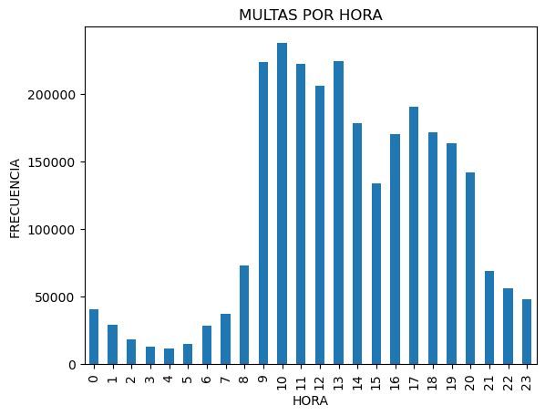

```python
import matplotlib.pyplot as plt

#Convertir la columna "Hora" a tipo entero
df_combinado3['HORA'] = df_combinado3['HORA'].astype(int)

#Contar la frecuencia de cada hora
frecuencia_horas = df_combinado3['HORA'].value_counts()

#Ordenar las horas de forma ascendente
frecuencia_horas = frecuencia_horas.sort_index()

#Crear un gráfico de barras para visualizar las horas con más multas
frecuencia_horas.plot(kind='bar')
plt.xlabel('HORA')
plt.ylabel('FRECUENCIA')
plt.title('MULTAS POR HORA')
plt.show()
```

**9-Muestra de forma gráfica las multas realizadas durante los meses de 2022. Bien es cierto que en la ciudad de Madrid hay mucho menos tráfico durante los meses de verano comprendidos entre mitad de Junio, Julio, Agosto y una pequeña parte de septiembre ¿Se observa esta afirmación en las visualizaciones?.**

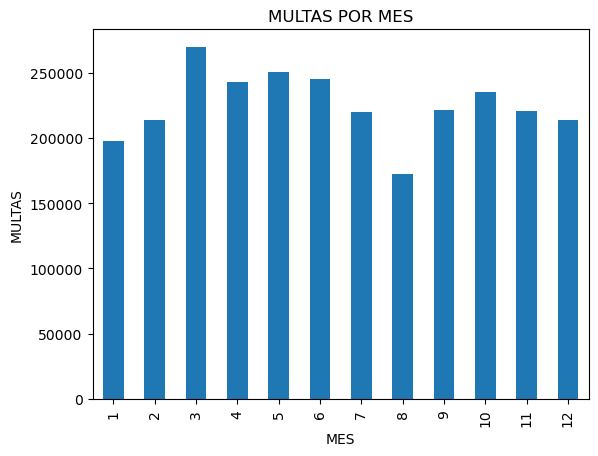

```python
#Contar la frecuencia de cada mes
mult_mes = df_combinado3['MES'].value_counts()

#Ordenar los meses de forma ascendente
mult_mes = mult_mes.sort_index()

#Crear un gráfico de barras para visualizar las multas por meses. Se puede ver que en enero y
#en verano (sobretodo en Agosto) una bajada de las multas
mult_mes.plot(kind='bar')
plt.xlabel('MES')
plt.ylabel('MULTAS')
plt.title('MULTAS POR MES')
plt.show()
```

**10-Muestra el número de infracciones de forma gráfica (sin frecuencia acumulada), de cada uno de los agentes públicos en función de la calificación de la infracción**

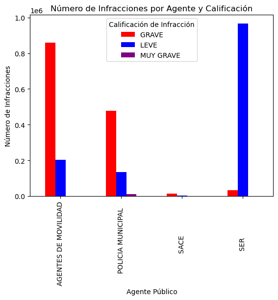

```python
#Agrupar los datos por 'DENUNCIANTE' y 'CALIFICACION' y contar el número de infracciones
infracciones_por_agente = df_combinado3.groupby(['DENUNCIANTE', 'CALIFICACION']).size().unstack()

#Crear un gráfico de barras para visualizar el número de infracciones por agente y calificación
infracciones_por_agente.plot(kind='bar', color= ['red', 'blue', 'purple'])
plt.xlabel('Agente Público')
plt.ylabel('Número de Infracciones')
plt.title('Número de Infracciones por Agente y Calificación')
plt.legend(title='Calificación de Infracción')
plt.show()
```